# 002 Single-HUC pipeline audit

```r
knitr::opts_chunk$set(
  echo = F,
  message = F,
  warning = F
)
```

### Initial decisions:

- `centroid_threshold_km <- 1`: We treat Maavara and MERIT catchments with centroids more than 1 km apart as mismatched, because this is a conservative spatial-identity filter meant to remove COMIDs where shared IDs may not represent the same landscape unit.
- `min_reaches <- 10`: We require at least 10 reaches for a monthly HUC-level allometry fit to be interpretable, because smaller samples can produce unstable slopes and misleading high or low $R^2$ values.
- `min_valid_months <- 6`: We require at least 6 valid months for a HUC to be considered seasonally supported, because this prevents conclusions from being driven by only one or a few months of coherent behavior.

| dataset | rows | comids |
| --- | --- | --- |
| Maavara catchments | 175116 | 175116 |
| MERIT catchments | 172591 | 172591 |
| MERIT flowlines | 172852 | 172852 |
| Metabolism | 2101392 | 175116 |

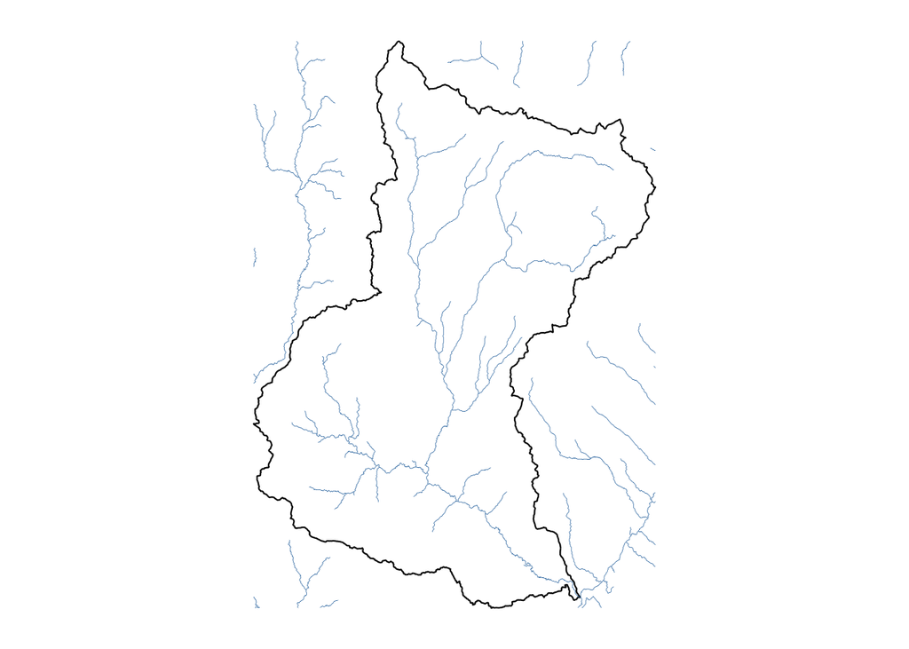

3. Compare HUC membership rules

The analysis domain is the set of focal reaches we will fit allometry for; here we compare several ways to assign COMIDs to the HUC.

| flowline_point | flowline_intersect | catchment_point | all_three | any_disagreement |
| --- | --- | --- | --- | --- |
| 69 | 69 | 69 | 69 | 0 |

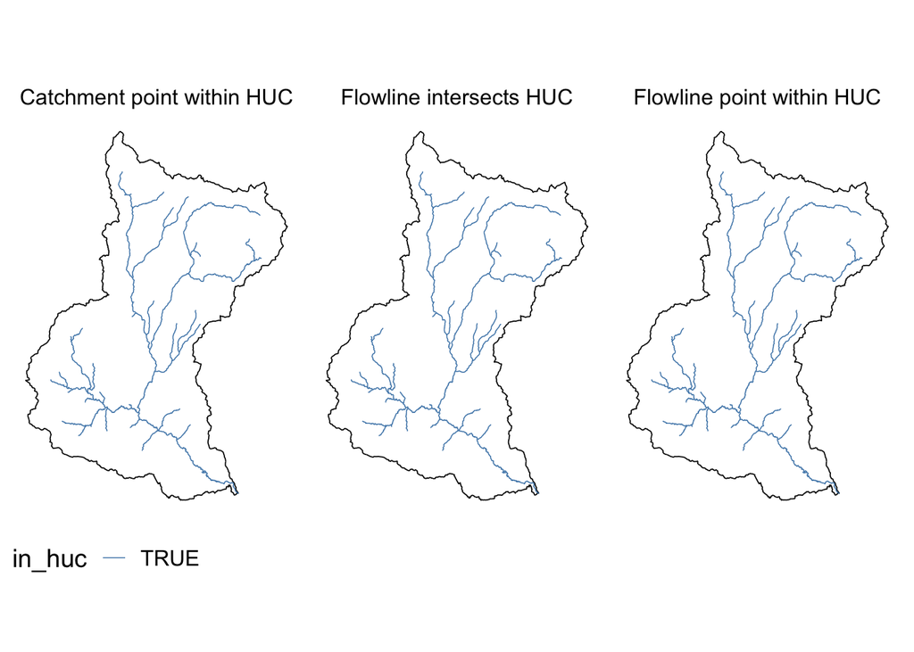

4. Build routing from MERIT flowlines

Routing is built from the MERIT comid -> nxt_dw relationship. The focal HUC is not assumed to be hydrologically closed.

Need to decide which method - will probably need to find a HUC where this varies

| focal_reaches | median_upstream_full | max_upstream_full | median_pct_upstream_within_huc | min_pct_upstream_within_huc |
| --- | --- | --- | --- | --- |
| 69 | 1 | 69 | 100 | 100 |

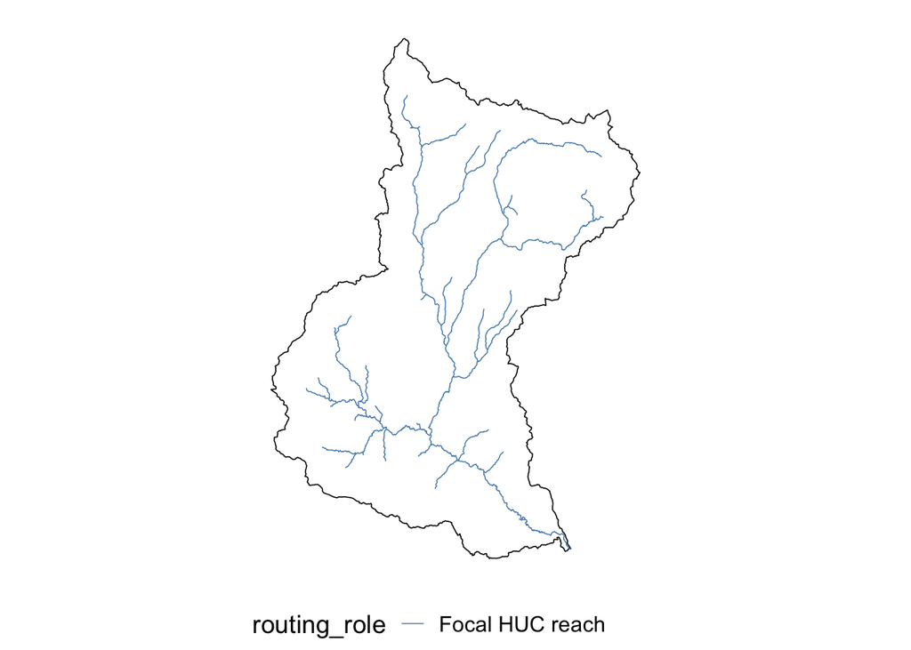

5. Maavara-MERIT centroid agreement

We compare Maavara and MERIT catchment centroids for all COMIDs needed by this single-HUC routing problem.

| centroid_status | n |
| --- | --- |
| match_le_0.1km | 69 |

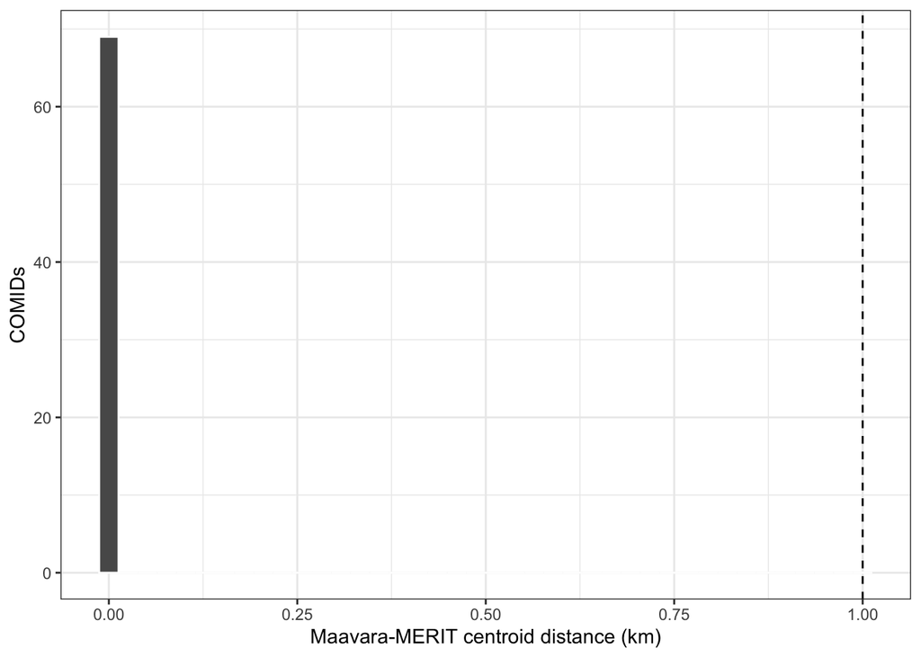

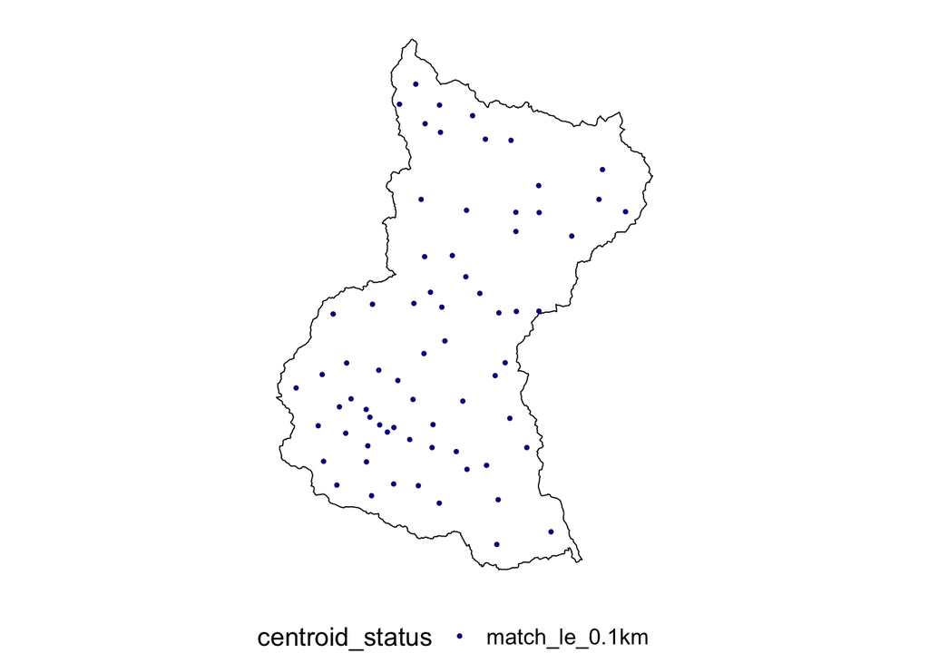

For the prototype calculation below, we keep only COMIDs with a successful centroid comparison within 1 km.

6. Join metabolism to geometry

Metabolism is stored as areal rates, so we multiply by estimated stream surface area before accumulating upstream.

| rows | comids | months | pct_missing_gpp | pct_missing_er | pct_missing_stream_area | pct_nonpositive_stream_area |
| --- | --- | --- | --- | --- | --- | --- |
| 828 | 69 | 12 | 0 | 0 | 0 | 0 |

| month | month_name | n |
| --- | --- | --- |
| 1 | Jan | 69 |
| 2 | Feb | 69 |
| 3 | Mar | 69 |
| 4 | Apr | 69 |
| 5 | May | 69 |
| 6 | Jun | 69 |
| 7 | Jul | 69 |
| 8 | Aug | 69 |
| 9 | Sep | 69 |
| 10 | Oct | 69 |
| 11 | Nov | 69 |
| 12 | Dec | 69 |

7. Compare accumulation domains

Here we distinguish focal reaches from upstream contributing reaches. This is the main audit for whether cumulative metabolism and upstream area describe the same spatial domain.

| focal_reaches | median_within_huc_to_merit | median_full_accum_to_merit | pct_within_huc_lt_50pct_merit | pct_full_accum_lt_90pct_merit |
| --- | --- | --- | --- | --- |
| 69 | 1 | 1 | 0 | 0 |

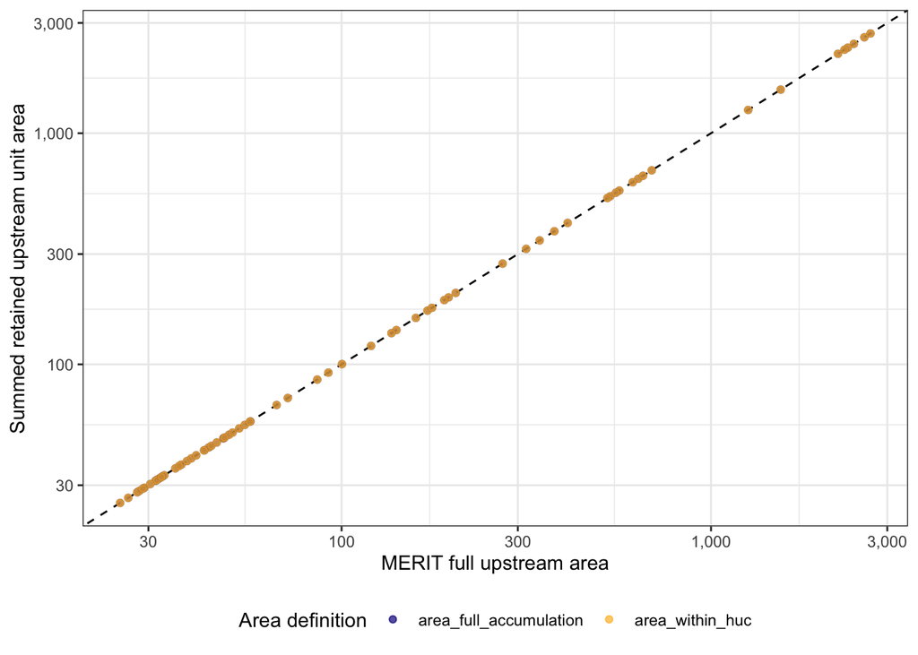

8. Calculate cumulative metabolism

We calculate cumulative metabolism two ways: using only upstream reaches inside the HUC, and using all retained upstream reaches available in the CONUS MERIT network.

| accumulation_domain | rows | downstream_comids | months | pct_zero_gpp | pct_zero_er |
| --- | --- | --- | --- | --- | --- |
| full_upstream_metabolism | 828 | 69 | 12 | 0 | 0 |
| within_huc_metabolism | 828 | 69 | 12 | 0 | 0 |

9. Fit candidate allometry definitions

We compare three candidate interpretations: HUC-local metabolism against full MERIT area, HUC-local metabolism against HUC-local area, and full upstream metabolism against the retained full upstream area.

| analysis_option | metabolism_var | months | median_n | median_slope | median_r2 |
| --- | --- | --- | --- | --- | --- |
| full_upstream_metabolism_vs_full_accumulation_area | ER | 12 | 69 | 1.522 | 0.867 |
| full_upstream_metabolism_vs_full_accumulation_area | GPP | 12 | 69 | 1.622 | 0.870 |
| within_huc_metabolism_vs_full_merit_area | ER | 12 | 69 | 1.522 | 0.867 |
| within_huc_metabolism_vs_full_merit_area | GPP | 12 | 69 | 1.622 | 0.870 |
| within_huc_metabolism_vs_within_huc_area | ER | 12 | 69 | 1.522 | 0.867 |
| within_huc_metabolism_vs_within_huc_area | GPP | 12 | 69 | 1.622 | 0.870 |

10. Visualize allometry for selected months

These plots are diagnostic: they show whether area-definition choices alter the visual scaling relationship.

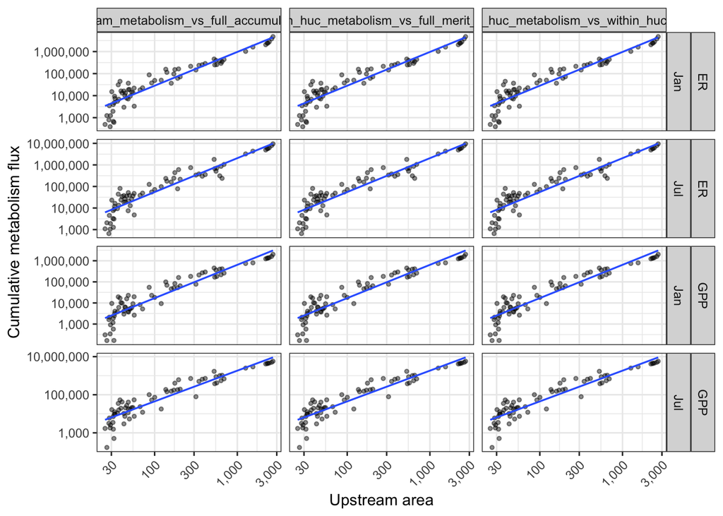

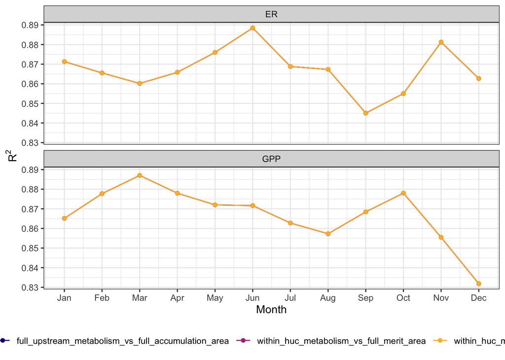

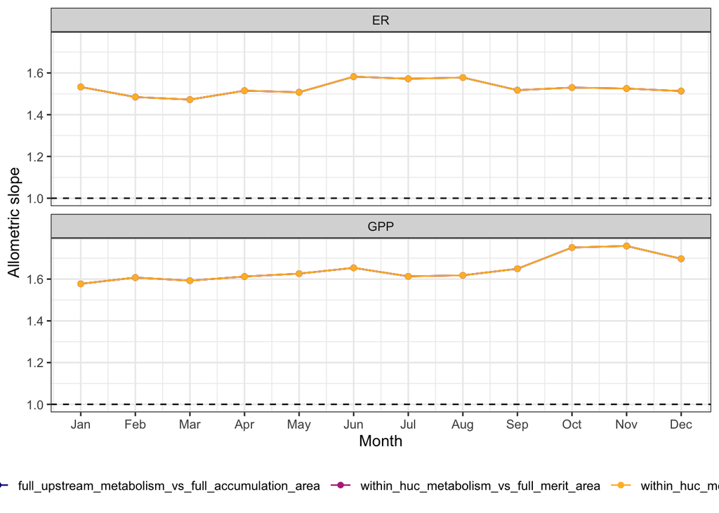

11. Diagnostic summary

This table summarizes the diagnostics we likely want to scale up later as one row per HUC8.

| huc | focal_comids_flowline_point | focal_comids_after_centroid_qc | relevant_comids_for_routing | centroid_mismatch_gt_1km | centroid_missing_comparison | median_pct_upstream_within_huc | median_within_huc_to_merit_area_ratio | median_full_accum_to_merit_area_ratio | metabolism_comids_available | metabolism_months_available |
| --- | --- | --- | --- | --- | --- | --- | --- | --- | --- | --- |
| 13020202 | 69 | 69 | 69 | 0 | 0 | 100 | 1 | 1 | 69 | 12 |

12. Interim interpretation notes HUC membership is a decision, not a fact; this prototype compares flowline-point, flowline-intersection, and catchment-point assignments. The focal HUC is not assumed to be hydrologically closed; upstream contributors can occur outside the focal HUC. The key allometry question is whether cumulative metabolism and upstream area are calculated over matching spatial domains. The scale-up version should retain these diagnostics rather than only saving final slopes.